# Segmentation: Deciding Which Items Get Attention

Manuel D. Rossetti, PhD P.E.

## Agenda

- What changes when you have forty thousand items instead of one
- Two reasons to group, which are not the same reason
- ABC classification, and where it misses
- Classifying by **demand pattern**, which selects the model
- What a shared policy costs, measured

## A Manager Does Not Have An Item

Everything in this course so far concerns **one item**.

A distributor carries tens of thousands of stock keeping units. A hospital system carries more.

Each one has a demand history, a lead time, a unit cost, a supplier, and a policy that has to come from **somewhere**.

## Computation Is Not What Breaks

A spreadsheet will produce forty thousand order quantities in a few seconds.

What breaks is everything **around** the computation. Someone has to

- decide which items deserve a considered decision instead of a default
- keep the inputs current as demand and costs move
- investigate the exceptions the system raises
- answer for the results

Those activities consume **people**, and people are finite in a way that arithmetic is not.

## The Attention Budget

A distributor stocks **12,000 items**. One planner, with about **30 hours a week** genuinely available for review. A considered review takes **six minutes**.

$$\frac{(30)(60)}{6} = 300 \text{ reviews per week}$$

$$300 \times 50 \text{ weeks} = 15{,}000 \text{ reviews per year}$$

Spread evenly across the portfolio:

$$\frac{15{,}000}{12{,}000} = 1.25 \text{ reviews per item per year}$$

## Now Try to Allocate It Sensibly

Suppose **8%** of items deserve monthly attention.

$$960 \text{ items} \times 12 = 11{,}520 \text{ reviews, leaving } 3{,}480$$

Give the next **17%** a quarterly review:

$$2{,}040 \text{ items} \times 4 = 8{,}160 \text{ more}$$

$$11{,}520 + 8{,}160 = 19{,}680 \quad\text{against a budget of}\quad 15{,}000$$

**It does not fit.**

## Fall Back, and Look at What Is Left

Review that middle group **once a year** instead: 2,040 reviews.

$$15{,}000 - 11{,}520 - 2{,}040 = 1{,}440 \text{ reviews left}$$

for the remaining **9,000 items**.

$$\frac{9{,}000}{1{,}440} = \text{one review per item every } \mathbf{6.25} \text{ years}$$

## Two Conclusions, Neither Depending on the Numbers

**Most items will never be looked at.** Not through neglect, by **arithmetic**. Whatever the portfolio size and however diligent the planner, the great majority of items must be handled by a rule that runs without anyone examining them.

**The scarce resource is attention, not computation.** Giving all 12,000 items even a quarterly review would take 48,000 reviews a year, which is **3.2 planners doing nothing else**.

The order quantities, by contrast, could be recomputed nightly at no meaningful cost.

## So What Does a Manager Actually Decide?

The models answer *how much* and *when*, for an item, once the inputs are known.

The manager decides **which items get a considered answer and which get a default**, and whether the inputs can be trusted at all.

Those are the two subjects of this chapter, and they come **before** the models rather than after them.

## Two Reasons to Group

**Grouping for attention.** Management effort is scarce and should go where it matters. An importance-based scheme ranks items so the few worth individual review can be identified.

**Grouping for policy.** Setting and maintaining a policy costs effort whether the item is important or not. An operations-based scheme puts items with similar **operating characteristics** together so one policy can serve them all.

These are not the same problem. Applying one where the other is needed is the commonest failure in practice.

## They Share No Row

|  | Grouping for attention | Grouping for policy |
| --- | --- | --- |
| Question answered | Which items deserve review? | Which items can share a policy? |
| Typical attributes | Annual dollar usage, criticality | Demand rate, unit cost, lead time, demand pattern |
| Typical method | ABC classification | Clustering |
| Number of groups | Three to six | Whatever the data supports |
| Judged by | Whether attention lands on the right items | Cost penalty against individual policies |

Not the question, not the attributes, not the method, not even the criterion by which the result is judged.

**A scheme built for one column is not evidence about the other.**

## Pareto, and the ABC Idea

Annual dollar usage is distributed very **unevenly** across items. A small fraction accounts for most of the money.

$$\text{annual dollar usage} = \lambda_{i}\,c_{i}$$

Rank by that product, cut the ranked list into classes, and attention concentrates where the money is.

- **Class A**: individual review, tight control
- **Class B**: in between
- **Class C**: a simple rule, infrequent attention

## Twelve Items, Ranked

| Item | $\lambda$ | $c$ | Annual usage | Cumulative % |
| --- | --- | --- | --- | --- |
| IT-01 | 1,200 | $75.00 | $90,000 | 51.4% |
| IT-02 | 60 | $520.00 | $31,200 | 69.3% |
| IT-03 | 9,000 | $2.40 | $21,600 | **81.6%** |
| IT-04 | 300 | $38.00 | $11,400 | 88.1% |
| IT-05 | 40 | $180.00 | $7,200 | 92.2% |
| IT-06 | 2,500 | $1.80 | $4,500 | **94.8%** |
| IT-07 to IT-12 |  |  | $9,078 | 100.0% |

Cutting at 80% and 95%: **three items out of twelve carry 82% of the expenditure**, and half the items carry 5%.

## The Concentration, Drawn

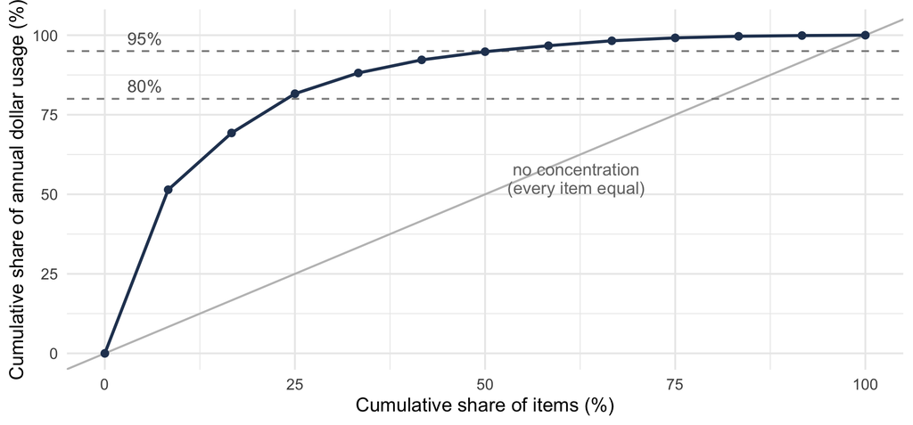

## Read the Gap

The diagonal is what the curve would look like if **every item carried the same annual dollar usage**.

The **gap between the curve and the diagonal is the concentration itself**.

An item file that plots close to the diagonal has no concentration to exploit, and ABC classification will not help there.

The steeper the early rise, the more a small class A buys you.

## The Cut Points Were Chosen, Not Derived

Moving the A boundary up **one item** would put 88% of the value in class A, at the cost of reviewing a third of the portfolio.

**Nothing in the data says where to stop.**

The conventional 80/15/5 split is a convention, not a result, and you should be prepared to defend the cut points you choose.

## One Criterion Misses, in Both Directions

**A high dollar usage item may be entirely undemanding**: readily available, substitutable, short lead time, no consequence to running out. It will be reviewed weekly because it is expensive.

**A low dollar usage item may be a fastener that halts an assembly line**, available from one supplier on a four month lead time. It will be reviewed annually because it is cheap.

Criticality is what dollar usage cannot see.

## Adding a Second Criterion

Score each item on dollar usage **and** criticality, each normalized, with equal weights:

$$\text{score}_{i} = 0.5\left(\frac{\lambda_{i}c_{i}}{\max_j \lambda_{j}c_{j}}\right)
+ 0.5\left(\frac{\text{criticality}_{i}-1}{4}\right)$$

**Seven of the twelve items change class.** Two movements matter most:

**IT-11 rises from C to A.** An eight cent part with $400 of annual usage, ranked eleventh of twelve on money and **third overall** once criticality counts.

**IT-02 falls from A to C.** The second most expensive line in the file at $31,200 a year, criticality 1: substitutable, no operational consequence. It was getting weekly attention because of its price tag alone.

## The Weakness of That Method

The weights were **chosen**. Nothing justified the 0.5. A manager who preferred 0.7 would get different classes, and no experiment settles the question.

The better line of attack **derives** the ranking statistic from the cost model rather than assembling it from opinions, folding unit cost, lead time, demand, and shortage cost into a single statistic the objective function implies.

Where a defensible cost model exists, do that. Where one does not, weighted scoring remains, and you should **record its weights as the assumptions they are**.

## Some Attributes Forbid Grouping Entirely

| Role | Meaning | Examples |
| --- | --- | --- |
| **Prevent** grouping | Items differing here must not share a group at all | Storage structure, strategic importance |
| **Weaken** grouping | Differences degrade a shared policy without forbidding it | Demand dispersion, lead time |
| **Useful** to the manager | Make the resulting groups actionable | Supplier, existing functional groups |

The first row is the one that gets skipped.

Two items stocked at **different echelons** serve different functions, so grouping them produces a policy correct for neither, however similar their demand rates.

Identify the preventing attributes **first**, and partition on them before any statistical method is applied.

## Demand Pattern: The Grouping That Selects a Model

Two items with identical annual demand can behave entirely differently. One sells four units every week; the other sells two hundred units twice a year.

Annual dollar usage **cannot tell them apart**.

Two statistics do:

$$\mathit{ADI} = \frac{\text{periods}}{\text{periods with non-zero demand}}
\qquad
\mathit{CV}^{2} = \left(\frac{s}{\bar{x}}\right)^{2}$$

Intermittence, and lumpiness.

## Four Classes

|  | Frequent ($\mathit{ADI} \le 1.32$) | Infrequent ($\mathit{ADI} > 1.32$) |
| --- | --- | --- |
| **Variable** ($\mathit{CV}^{2} > 0.49$) | Erratic | **Lumpy** |
| **Steady** ($\mathit{CV}^{2} \le 0.49$) | **Smooth** | Intermittent |

| Item | Demand by period | $\mathit{ADI}$ | $\mathit{CV}^{2}$ | Class |
| --- | --- | --- | --- | --- |
| S-1 | 20, 22, 19, 21, … | 1.00 | 0.005 | Smooth |
| E-1 | 5, 40, 2, 60, … | 1.00 | 0.798 | Erratic |
| I-1 | 0, 10, 0, 0, 9, … | 3.00 | 0.007 | Intermittent |
| L-1 | 0, 0, 45, 0, 0, 3, … | 3.00 | 1.001 | Lumpy |
| B-1 | 0, 15, 12, 0, 18, … | 1.50 | 0.018 | Intermittent |

## Why This One Selects the Model

The stochastic policies later in this course **assume a demand distribution** that a smooth item satisfies and a lumpy one does not.

A fill rate computed for a lumpy item from a normal approximation can be badly wrong.

Look at **B-1**. Demand in eight of twelve periods, very steady sizes. It reads as a well behaved item.

But $\mathit{ADI} = 1.50$ puts it just past the 1.32 cut, into the intermittent class.

Do not let an item sitting that close to a boundary have its treatment decided by which side it fell on.

## Two Cautions

**The thresholds are conventions.** The literature does not agree on when a series becomes intermittent.

**The class depends on the period length you chose.** The same transactions bucketed daily rather than monthly show more zero periods and a longer inter-demand interval.

An item can be moved between classes by changing **nothing but the reporting calendar**. Never allow such a result to drive a policy.

A portfolio is rarely mostly smooth. In a hospital pharmacy study of roughly two thousand items, most fell **outside** the smooth class. That is the normal case, not a pathology.

## What Does a Shared Policy Cost?

A classification is not right or wrong. It is **more or less expensive**, and the cost is measurable.

$$\text{penalty} =
\frac{C(\text{group policies}) - C(\text{individual policies})}
{C(\text{individual policies})}$$

Use the **relevant** cost, not total cost. Purchase cost is identical under every grouping, so it cancels in the numerator and only inflates the denominator.

Dividing by $\mathit{TC}$ would make the same grouping look cheap for an expensive item and dear for a cheap one, which is a statement about unit cost and not about grouping.

## Six Items, Three Schemes

| Item | Individual | Two groups | Three groups |
| --- | --- | --- | --- |
| A | $4,200 | $4,310 | $4,250 |
| B | $3,800 | $3,905 | $3,845 |
| C | $5,100 | $5,180 | $5,140 |
| D | $1,150 | $1,260 | $1,200 |
| E | $980 | $1,090 | $1,030 |
| F | $1,340 | $1,415 | $1,370 |
| **Total** | **$16,570** | **$17,160** | **$16,835** |

$$\frac{17{,}160 - 16{,}570}{16{,}570} = 3.56\%
\qquad
\frac{16{,}835 - 16{,}570}{16{,}570} = 1.60\%$$

## What the Penalty Buys

$590 a year against $265 a year, set against maintaining two policies, three, or six.

For **six items** this is not a decision anybody needs to make. Anyone can maintain six policies.

Scale it to **forty thousand items** and the same 3.56% is the price of reducing forty thousand policy calculations to two hundred: the difference between a procedure that runs and one that does not.

The penalty is the **same number** either way. What changes is what it buys.

## A Classification Earns Its Place Only Through Decisions

| Decision | How the class enters |
| --- | --- |
| Review frequency | A items individually and often, C items on a rule |
| Service target | Higher fill rates for critical or high value classes |
| Count frequency | More frequent cycle counts for A items |
| Stocking decision | Whether to hold the item at a location at all |
| Policy sharing | Group policy, or each item set individually |

A class appearing in **none** of those rows is changing nothing. It is decoration that costs money to produce.

## Three Failures That Recur

**Classes become ends in themselves.** A quarterly report of how many items are in each class, with no decision attached.

**Boundaries are treated as cliffs.** The item just below the A cut and the item just above it are nearly identical. Where a decision is sensitive at a boundary, look at the **items** near it, not at the rule.

**Classes go stale.** Demand moves, products reach end of life, criticality changes when equipment is retired. A classification built three years ago is directing today’s attention using **yesterday’s item file**.

## What We Did Today

**Attention is the binding constraint.** 1.25 reviews per item per year, and most items will never be looked at.

**Two reasons to group, sharing no row.** A ranking says nothing about whether two items can share a policy.

**One criterion misses in both directions.** Seven of twelve items changed class once criticality counted.

**Demand pattern selects the model**, and the class depends on the calendar you chose.

**A grouping is judged by its cost penalty**, against the policies it saves maintaining.

## For Next Time

**Read before next session:** *Inventory Record Analysis*.

Next session:

- Why a policy reads a **record**, not a shelf, and why records drift
- What record error actually costs, measured on a two-echelon chain
- Three definitions of record accuracy that give **40%, 70%, and 98.6%** on one count sheet
- Cycle counting: which methods, how often, and why correcting records is the by-product rather than the purpose

Both halves of this chapter are prerequisites in the strong sense. A policy can be derived perfectly and still fail, either because it was applied to items that should never have had individual treatment, or because it was computed from quantities that were not true.

⌂ Index